# S2_Poisson

Author

Alfredo Aro

# Sesión 2: Regresión Poisson

Material referencial: José Manuel Magallanes Reyes

## 1. Introducción

Observemos esta data!

```r
rm(list = ls())  #limpiamos nuestro environment

library(rio)   #paquete
censo2007=import("https://github.com/Estadistica-AnalisisPolitico/Sesion3/raw/main/data2007peru.xlsx")

head(censo2007)
```

```
  Pais Departamento Provincia Distrito              Tema
1 Perú     Amazonas     Bagua Aramango       Demográfico
2 Perú     Amazonas     Bagua Aramango       Demográfico
3 Perú     Amazonas     Bagua Aramango       Demográfico
4 Perú     Amazonas     Bagua Aramango       Demográfico
5 Perú     Amazonas     Bagua Aramango       Demográfico
6 Perú     Amazonas     Bagua Aramango Económico-Laboral
                         Sub Tema
1                         General
2                         General
3                         General
4                         General
5                         General
6 Población Económicamente Activa
                                                                     Descripcion
1                                             Total de habitantes del censo 2007
2                                             Total de habitantes del censo 2007
3                                             Total de habitantes del censo 2007
4                                             Total de habitantes del censo 2007
5                                             Total de habitantes del censo 2007
6 Porcentaje de Trabajadores Independientes o por cuenta propia no profesionales
          Clase Indicadores Valor
1         Total          NA 11442
2   Área Urbana          NA  2657
3    Área Rural          NA  8785
4 Sexo - Hombre          NA  6141
5  Sexo - Mujer          NA  5301
6         Total          NA 54.61
```

Vemos qué tipos de datos estamos manejando y cómo es que los lee R

```r
str(censo2007)
```

```
'data.frame':   36620 obs. of  10 variables:
 $ Pais        : chr  "Perú" "Perú" "Perú" "Perú" ...
 $ Departamento: chr  "Amazonas" "Amazonas" "Amazonas" "Amazonas" ...
 $ Provincia   : chr  "Bagua" "Bagua" "Bagua" "Bagua" ...
 $ Distrito    : chr  "Aramango" "Aramango" "Aramango" "Aramango" ...
 $ Tema        : chr  "Demográfico" "Demográfico" "Demográfico" "Demográfico" ...
 $ Sub Tema    : chr  "General" "General" "General" "General" ...
 $ Descripcion : chr  "Total de habitantes del censo 2007" "Total de habitantes del censo 2007" "Total de habitantes del censo 2007" "Total de habitantes del censo 2007" ...
 $ Clase       : chr  "Total" "Área Urbana" "Área Rural" "Sexo - Hombre" ...
 $ Indicadores : logi  NA NA NA NA NA NA ...
 $ Valor       : chr  "11442" "2657" "8785" "6141" ...
```

Lo más notorio es que la columna **Valor** ha sido interpretada como texto y no cómo tipo numérico. R hará eso si es que alguna celda tiene un carácter que no sea número o punto. Veamos:

```r
#vemos qué celda tiene algo que no sea número
censo2007$Valor[!grepl("[0-9]", censo2007$Valor)]
```

```
 [1] "-" "-" "-" "-" "-" "-" "-" "-" "-" "-" "-" "-" "-" "-" "-" "-" "-" "-" "-"
[20] "-" "-" "-" "-" "-" "-" "-" "-" "-" "-" "-" "-" "-" "-" "-" "-" "-" "-" "-"
[39] "-" "-" "-" "-" "-" "-" "-" "-" "-" "-" "-" "-" "-" "-" "-" "-" "-" "-" "-"
[58] "-" "-" "-" "-" "-" "-" "-" "-" "-" "-" "-" "-" "-" "-" "-" "-" "-" "-" "-"
[77] "-" "-"
```

Sabiendo ello, podemos convertir la columna a numérico sin temor a perder valores:

```r
censo2007$Valor=as.numeric(censo2007$Valor)
```

Sin embargo, no usaremos todas las columnas, buscamos unas cuantas

```r
censo2007_sub=censo2007[,-c(1,5,6,9)] # -c() elimina esas columnas
str(censo2007_sub)
```

```
'data.frame':   36620 obs. of  6 variables:
 $ Departamento: chr  "Amazonas" "Amazonas" "Amazonas" "Amazonas" ...
 $ Provincia   : chr  "Bagua" "Bagua" "Bagua" "Bagua" ...
 $ Distrito    : chr  "Aramango" "Aramango" "Aramango" "Aramango" ...
 $ Descripcion : chr  "Total de habitantes del censo 2007" "Total de habitantes del censo 2007" "Total de habitantes del censo 2007" "Total de habitantes del censo 2007" ...
 $ Clase       : chr  "Total" "Área Urbana" "Área Rural" "Sexo - Hombre" ...
 $ Valor       : num  11442 2657 8785 6141 5301 ...
```

Contamos con un problema más! Nuestro data frame se encuentra en formato **long**:

```r
library(magrittr)
head(censo2007_sub,20)%>%
    rmarkdown::paged_table(options = )
```

|  | Departamento | Provincia | Distrito | Descripcion | Clase | Valor |
| --- | --- | --- | --- | --- | --- | --- |
| 1 | Amazonas | Bagua | Aramango | Total de habitantes del censo 2007 | Total | 11442.00 |
| 2 | Amazonas | Bagua | Aramango | Total de habitantes del censo 2007 | Área Urbana | 2657.00 |
| 3 | Amazonas | Bagua | Aramango | Total de habitantes del censo 2007 | Área Rural | 8785.00 |
| 4 | Amazonas | Bagua | Aramango | Total de habitantes del censo 2007 | Sexo - Hombre | 6141.00 |
| 5 | Amazonas | Bagua | Aramango | Total de habitantes del censo 2007 | Sexo - Mujer | 5301.00 |
| 6 | Amazonas | Bagua | Aramango | Porcentaje de Trabajadores Independientes o por cuenta propia no profesionales | Total | 54.61 |
| 7 | Amazonas | Bagua | Aramango | Porcentaje de Trabajadores Independientes o por cuenta propia no profesionales | Área Urbana | 46.66 |
| 8 | Amazonas | Bagua | Aramango | Porcentaje de Trabajadores Independientes o por cuenta propia no profesionales | Área Rural | 57.23 |
| 9 | Amazonas | Bagua | Aramango | Porcentaje de Trabajadores Independientes o por cuenta propia no profesionales | Sexo - Hombre | 58.28 |
| 10 | Amazonas | Bagua | Aramango | Porcentaje de Trabajadores Independientes o por cuenta propia no profesionales | Sexo - Mujer | 36.28 |

[output cut: 10 more lines]

Pasémoslo a formato **wide**:

```r
library(reshape2)
censo2007_wide=dcast(data=censo2007_sub,
                     formula=Departamento+Provincia+Distrito ~ Descripcion+Clase,
                     value.var="Valor")

head(censo2007_wide)
```

```
  Departamento Provincia   Distrito
1     Amazonas     Bagua   Aramango
2     Amazonas     Bagua   Copallin
3     Amazonas     Bagua   El Parco
4     Amazonas     Bagua      Imaza
5     Amazonas     Bagua    La Peca
6     Amazonas   Bongará Chisquilla
  Personas que tienen algún tipo de seguro_Área Rural
1                                                3933
2                                                1713
3                                                 274
4                                                9859
5                                                2568
6                                                 126
  Personas que tienen algún tipo de seguro_Área Urbana
```

[output cut: 132 more lines]

Los nombres de columnas son muy largos luego de esta conversión serán muy largos:

```r
names(censo2007_wide)
```

```
 [1] "Departamento"
 [2] "Provincia"
 [3] "Distrito"
 [4] "Personas que tienen algún tipo de seguro_Área Rural"
 [5] "Personas que tienen algún tipo de seguro_Área Urbana"
 [6] "Personas que tienen algún tipo de seguro_Sexo - Hombre"
 [7] "Personas que tienen algún tipo de seguro_Sexo - Mujer"
 [8] "Personas que tienen algún tipo de seguro_Total"
 [9] "Porcentaje de personas analfabetas de 15 años y más_Área Rural"
[10] "Porcentaje de personas analfabetas de 15 años y más_Área Urbana"
[11] "Porcentaje de personas analfabetas de 15 años y más_Sexo - Hombre"
[12] "Porcentaje de personas analfabetas de 15 años y más_Sexo - Mujer"
[13] "Porcentaje de personas analfabetas de 15 años y más_Total"
[14] "Porcentaje de Trabajadores Independientes o por cuenta propia no profesionales_Área Rural"
[15] "Porcentaje de Trabajadores Independientes o por cuenta propia no profesionales_Área Urbana"
[16] "Porcentaje de Trabajadores Independientes o por cuenta propia no profesionales_Sexo - Hombre"
[17] "Porcentaje de Trabajadores Independientes o por cuenta propia no profesionales_Sexo - Mujer"
[18] "Porcentaje de Trabajadores Independientes o por cuenta propia no profesionales_Total"
[19] "Total de habitantes del censo 2007_Área Rural"
[20] "Total de habitantes del censo 2007_Área Urbana"
[21] "Total de habitantes del censo 2007_Sexo - Hombre"
[22] "Total de habitantes del censo 2007_Sexo - Mujer"
[23] "Total de habitantes del censo 2007_Total"
```

Cambiamos los nombres:

```r
# uso de gsub()
# donde diga "Area Rural" cambiar a "rural":
names(censo2007_wide)=gsub(pattern = "Área Rural",
                           replacement = "rural",
                           x = names(censo2007_wide))

names(censo2007_wide)=gsub(pattern = "Área Urbana",
                           replacement = "urban",
                           x = names(censo2007_wide))

names(censo2007_wide)=gsub(pattern = "Sexo - Hombre",
                           replacement = "Hombre",
                           x = names(censo2007_wide))

names(censo2007_wide)=gsub(pattern = "Sexo - Mujer",
                           replacement = "Mujer",
                           x = names(censo2007_wide))

names(censo2007_wide)=gsub(pattern = "Sexo - Mujer",
                           replacement = "Mujer",
                           x = names(censo2007_wide))

names(censo2007_wide)=gsub(pattern = "Personas que tienen algún tipo de seguro",
                           replacement = "conSeguro",
                           x = names(censo2007_wide))

names(censo2007_wide)=gsub(pattern = "Porcentaje de personas analfabetas de 15 años y más",
                           replacement = "analfa",
                           x = names(censo2007_wide))

names(censo2007_wide)=gsub(pattern = "Porcentaje de Trabajadores Independientes o por cuenta propia no profesionales",
                           replacement = "indep",
                           x = names(censo2007_wide))

names(censo2007_wide)=gsub(pattern = "Total de habitantes del censo 2007",
                           replacement = "poblacion",
                           x = names(censo2007_wide))

# nuevos nombres
names(censo2007_wide)
```

```
 [1] "Departamento"     "Provincia"        "Distrito"         "conSeguro_rural"
 [5] "conSeguro_urban"  "conSeguro_Hombre" "conSeguro_Mujer"  "conSeguro_Total"
 [9] "analfa_rural"     "analfa_urban"     "analfa_Hombre"    "analfa_Mujer"
[13] "analfa_Total"     "indep_rural"      "indep_urban"      "indep_Hombre"
[17] "indep_Mujer"      "indep_Total"      "poblacion_rural"  "poblacion_urban"
[21] "poblacion_Hombre" "poblacion_Mujer"  "poblacion_Total"
```

¿Cómo nos quedaríamos por ahora con las columnas de “Totales”?

```r
# grep() devuelve las posiciones
grep(pattern = "Total",names(censo2007_wide))
```

```
[1]  8 13 18 23
```

Procedamos

```r
colsTotal=grep(pattern = "Total",names(censo2007_wide))
censo2007_wide_Totales=censo2007_wide[,c(1,2,3,colsTotal)]

# ahora:
head(censo2007_wide_Totales)
```

```
  Departamento Provincia   Distrito conSeguro_Total analfa_Total indep_Total
1     Amazonas     Bagua   Aramango            5057        13.81       54.61
2     Amazonas     Bagua   Copallin            2593        13.46       35.05
3     Amazonas     Bagua   El Parco             524        12.17       20.91
4     Amazonas     Bagua      Imaza           11294        17.29       47.94
5     Amazonas     Bagua    La Peca           14310         7.62       36.51
6     Amazonas   Bongará Chisquilla             206         3.29       42.95
  poblacion_Total
1           11442
2            6126
3            1274
4           21409
5           31506
6             346
```

Planteamos la primera hipótesis:

**Hipótesis: A nivel distrital, la cantidad de personas con algún seguro de salud está afectada por el nivel de analfabetismo**

Como vimos la anterior clase, podemos plantear un modelo de regresión lineal, una regresión Gaussiana

```r
library(knitr)
library(modelsummary)
h1=formula(conSeguro_Total~analfa_Total)

rl1=lm(h1, data = censo2007_wide_Totales)

model1=list('OLS asegurados (I)'=rl1)
modelsummary(model1, title = "Resumen de Regresion Lineal",
             stars = TRUE,
             output = "kableExtra")
```

Resumen de Regresion Lineal

|  | &nbsp;OLS asegurados (I) |
| --- | --- |
| (Intercept) | 12397.369*** |
|  | (748.564) |
| analfa_Total | -444.967*** |
|  | (45.970) |
| Num.Obs. | 1831 |
| R2 | 0.049 |
| R2 Adj. | 0.048 |
| AIC | 40986.3 |
| BIC | 41002.8 |
| Log.Lik. | -20490.143 |
| F | 93.694 |
| RMSE | 17531.34 |

+ p < 0.1, * p < 0.05, ** p < 0.01, *** p < 0.001

Como vemos en la Tabla, el covariado (conocido como predictor o variable independiente) salió con un valor absoluto alto, negativo, y significativo (es muy poco probable - menos de 0.1% - que no tenga efecto), pero con un R-2 ajustado muy bajo. Como el modelo no nos da buen *ajuste*, es muy probable que la evaluación del modelo no sea satisfactoria. Así, vemos en la Figura que difícilmente este modelo puede ser útil.

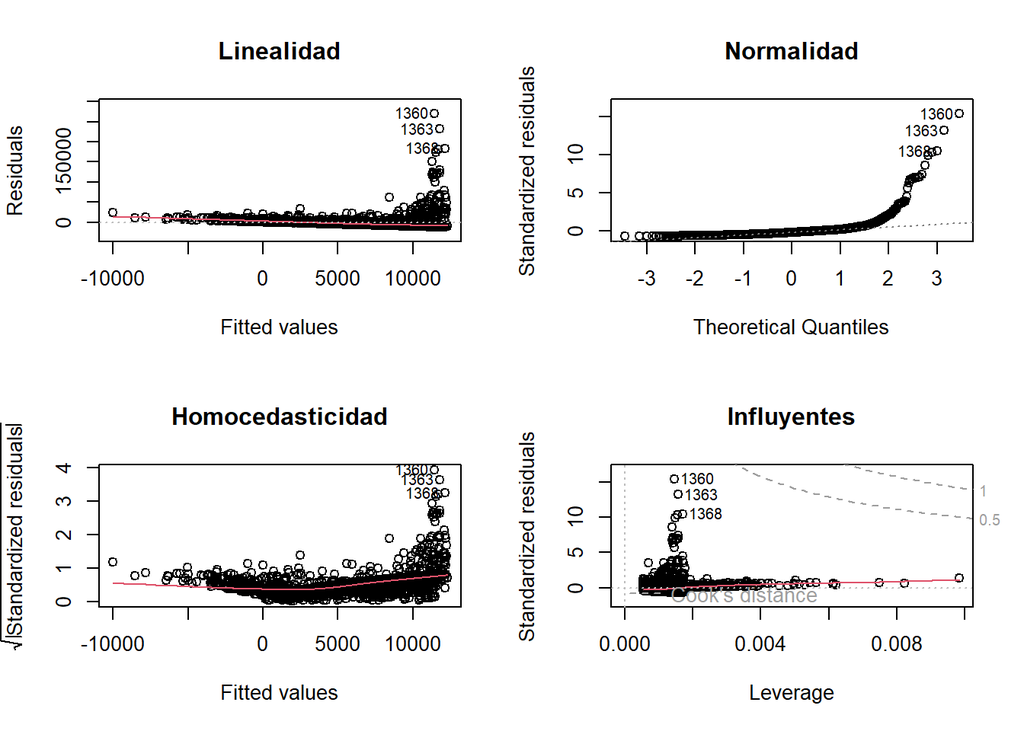

```r
par(mfrow = c(2, 2))
plot(rl1, 1,caption = '');title(main="Linealidad")
plot(rl1, 2, caption = '');title(main="Normalidad")
plot(rl1, 3, caption = '');title(main="Homocedasticidad")
plot(rl1, 5, caption = '');title(main="Influyentes")
```

Pensemos, podríamos señalar que si controlamos el tamaño de la población en el modelo podría mejorar

```r
library(knitr)
library(modelsummary)

h1control=formula(conSeguro_Total~analfa_Total + poblacion_Total )

rl2=lm(h1control, data = censo2007_wide_Totales)

modelslm=list('OLS asegurados (I)'=rl1,'OLS asegurados (II)'=rl2)
modelsummary(modelslm, title = "Regresiones Lineales",
             stars = TRUE,
             output = "kableExtra")
```

Regresiones Lineales

|  | &nbsp;OLS asegurados (I) | &nbsp;OLS asegurados (II) |
| --- | --- | --- |
| (Intercept) | 12397.369*** | 710.956*** |
|  | (748.564) | (189.771) |
| analfa_Total | -444.967*** | -12.293 |
|  | (45.970) | (11.186) |
| poblacion_Total |  | 0.387*** |
|  |  | (0.002) |
| Num.Obs. | 1831 | 1831 |
| R2 | 0.049 | 0.946 |
| R2 Adj. | 0.048 | 0.946 |
| AIC | 40986.3 | 35719.9 |
| BIC | 41002.8 | 35742.0 |
| Log.Lik. | -20490.143 | -17855.965 |
| F | 93.694 | 16156.363 |
| RMSE | 17531.34 | 4159.25 |

+ p < 0.1, * p < 0.05, ** p < 0.01, *** p < 0.001

Se ve una mejora en el R2, una gran mejora

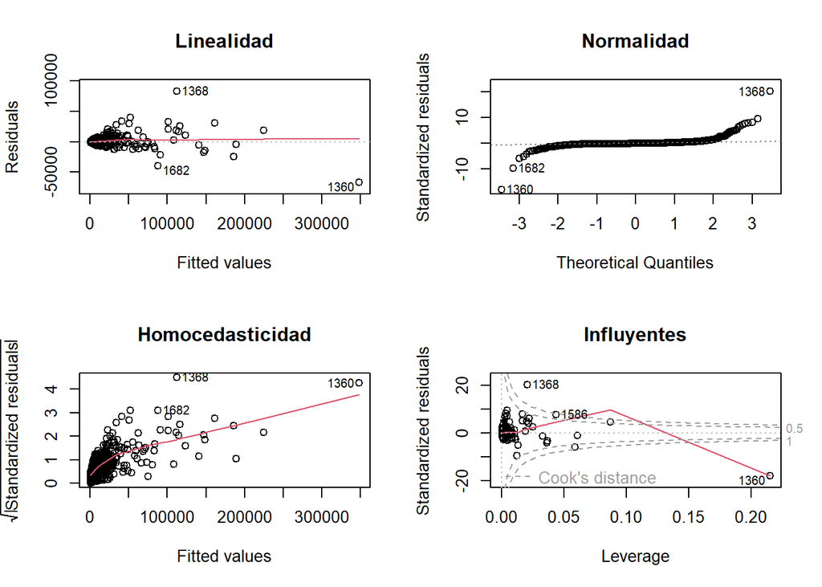

```r
par(mfrow = c(2, 2))
plot(rl2, 1,caption = '');title(main="Linealidad")
plot(rl2, 2, caption = '');title(main="Normalidad")
plot(rl2, 3, caption = '');title(main="Homocedasticidad")
plot(rl2, 5, caption = '');title(main="Influyentes")
```

Si bien mejora la situación, observamos que nuestro predictor dejó de ser significativo ante la presencia de la variable de control. Quizá debamos analizar antes la naturaleza de la variable dependiente.

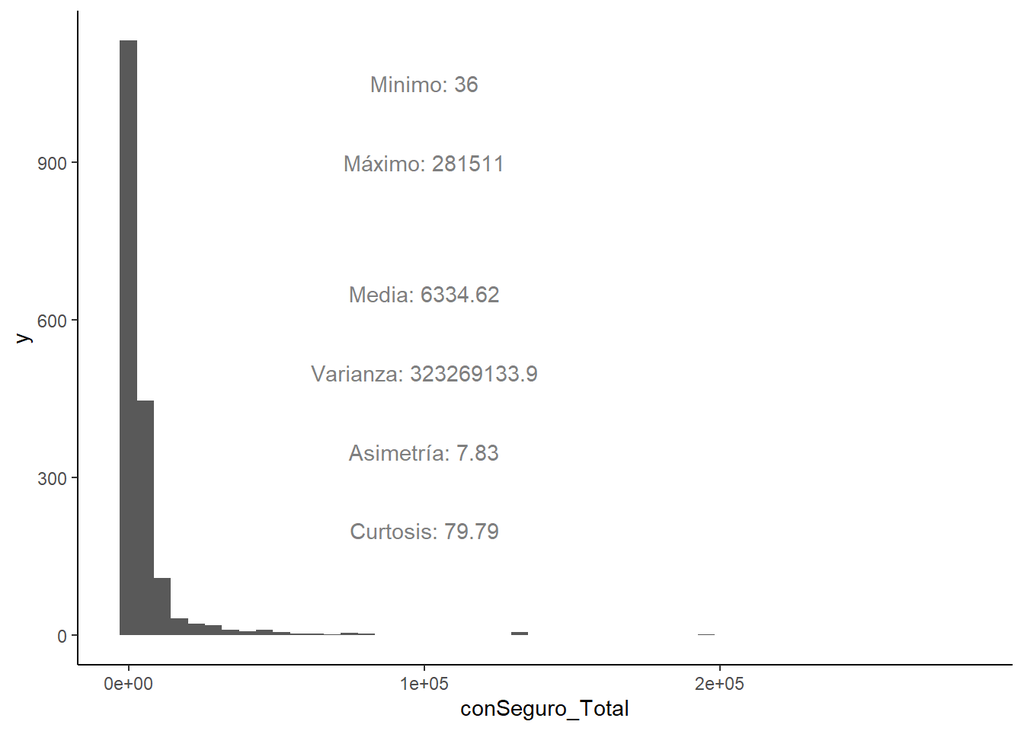

```r
library(ggplot2)
VarDep=censo2007_wide_Totales$conSeguro_Total
descris=list(min=min(VarDep),
             max=max(VarDep),
             media=round(mean(VarDep),2),
             var=round(var(VarDep),2),
             asim=round(e1071::skewness(VarDep),2),
             kurt=round(e1071::kurtosis(VarDep),2))

base=ggplot(data=censo2007_wide_Totales, aes(x=conSeguro_Total)) + theme_classic()
hist=base + geom_histogram(bins=50)
histInfo=hist + annotate("text", x = 100000, y = 1050,
                         color='grey50',
                       label = paste0("Minimo: ",descris$min))
histInfo = histInfo + annotate("text", x = 100000, y = 900,
                       color='grey50',
                       label = paste0("Máximo: ",descris$max))

histInfo = histInfo + annotate("text", x = 100000, y = 650,
                       color='grey50',
                       label = paste0("Media: ",descris$media))

histInfo = histInfo + annotate("text", x = 100000, y = 500,
                       color='grey50',
                       label = paste0("Varianza: ",descris$var))

histInfo = histInfo + annotate("text", x = 100000, y = 350,
                       color='grey50',
                       label = paste0("Asimetría: ",descris$asim))

histInfo = histInfo + annotate("text", x = 100000, y = 200,
                       color='grey50',
                       label = paste0("Curtosis: ",descris$kurt))

histInfo
```

## 2. Regresión Poisson

La regresión Poisson tiene sus supuestos (Glen 2016):

1. **Variable Respuesta:** Es un conteo (Y) por unidad de tiempo o espacio, que puede ser descrita por la distribución Poisson (por ejemplo *asaltos* por dia). Puede además ser un ratio (λλ) cuando la unidad de tiempo o espacio varía para cada conteo (por ejemplo *votos a favor* del *total de votos*) .
2. **Independencia:** Las observaciones (filas) no deben tener relación entre sí.
3. **Media=Varianza** Por definición, la media de una variable que se distribuye como Poisson debe ser igual a su varianza (equidispersión). Si la varianza supera significativamente a la media hablamos de sobredispersión; pero si la media fuera mucho mayor que la varianza tendríamos subdispersión.
4. **Linealidad:** El logaritmo de la variable dependiente (los conteos) debe ser una función lineal de los covariados.

Replanteamos nuestra hipótesis para el modelo Poisson

```r
rp1=glm(h1, data = censo2007_wide_Totales,
        offset=log(poblacion_Total), #exposure, variable de control
        family = poisson(link = "log"))

# displaying results
modelslmpoi=list('OLS asegurados (II)'=rl2,
                 'POISSON asegurados'=rp1)

modelsummary(modelslmpoi, title = "Regresiones OLS y Poisson",
             stars = TRUE,
             output = "kableExtra")
```

Regresiones OLS y Poisson

|  | &nbsp;OLS asegurados (II) | &nbsp;POISSON asegurados |
| --- | --- | --- |
| (Intercept) | 710.956*** | -0.900*** |
|  | (189.771) | (0.000) |
| analfa_Total | -12.293 | 0.005*** |
|  | (11.186) | (0.000) |
| poblacion_Total | 0.387*** |  |
|  | (0.002) |  |
| Num.Obs. | 1831 | 1831 |
| R2 | 0.946 |  |
| R2 Adj. | 0.946 |  |
| AIC | 35719.9 | 895923.3 |
| BIC | 35742.0 | 895934.4 |
| Log.Lik. | -17855.965 | -447959.669 |
| F | 16156.363 | 21585.036 |
| RMSE | 4159.25 | 4353.10 |

+ p < 0.1, * p < 0.05, ** p < 0.01, *** p < 0.001

Ahora notamos que al correr nuestra regresión Poisson, nuestra variable independiente vuelve a tener efecto sobre la dependiente. OJO: No siempre es necesario emplear el offset, pero en este caso sí, pues estamos controlando la exposure de manera explícita (población). Sin embargo, vemos que el AIC de la Poisson resulta mayor que el de la Gaussiana.

### 2.1. Interpretación

Ya sabemos cómo usar una regresión Poisson, pero no sabemos interpretarla. Planteamos una nueva hipótesis

**Important**

**A nivel distrital, la cantidad de personas con algún seguro de salud está afectada por el nivel de analfabetismo y por la presencia de trabajadores independientes.**

```r
h2=formula(conSeguro_Total~analfa_Total + indep_Total)

rp2=glm(h2, data = censo2007_wide_Totales,
        offset=log(poblacion_Total),
        family = poisson(link = "log"))


modelsPois=list('POISSON asegurados (I)'=rp1,
                'POISSON asegurados (II)'=rp2)
modelsummary(modelsPois,
             title = "Regresiones Poisson anidadas",
             stars = TRUE,
             output = "kableExtra")
```

Regresiones Poisson anidadas

|  | &nbsp;POISSON asegurados (I) | &nbsp;POISSON asegurados (II) |
| --- | --- | --- |
| (Intercept) | -0.900*** | -0.615*** |
|  | (0.000) | (0.001) |
| analfa_Total | 0.005*** | 0.016*** |
|  | (0.000) | (0.000) |
| indep_Total |  | -0.011*** |
|  |  | (0.000) |
| Num.Obs. | 1831 | 1831 |
| AIC | 895923.3 | 771399.1 |
| BIC | 895934.4 | 771415.6 |
| Log.Lik. | -447959.669 | -385696.535 |
| F | 21585.036 | 75214.880 |
| RMSE | 4353.10 | 3748.51 |

+ p < 0.1, * p < 0.05, ** p < 0.01, *** p < 0.001

La interpretación de la Tabla NO ES DIRECTA COMO EN EL CASO DE LA GAUSS. Podemos empezar realizando una interpretación simple, sin hacer ningún cálculo

- En el modelo II ambos predictores son significativos
- En el modelo II, a mayor analfabetismo, mayor cantidad de asegurados
- En el modelo II, a mayor cantidad de trabajadores independientes, menor cantidad de asegurados.

Sin embargo, la interpretación precisa de los coeficientes de la Tabla requiere más cálculos. En este caso los coeficientes necesitan ser exponenciados para saber el eefecto sobre Y. Veamos la siguiente tabla

```r
# formula para limitar a 4 digitos decimales,
# sin que se muestre notación científica:
formatoNum <- function(x) format(x, digits = 4, scientific = FALSE)

modelsummary(modelsPois,
             fmt=formatoNum, # uso mi formula
             exponentiate = T, # exponenciar!!!!!
             statistic = 'conf.int',
             title = "Regresión Poisson - coeficientes exponenciados",
             stars = TRUE,
             output = "kableExtra")
```

Regresión Poisson - coeficientes exponenciados

|  | &nbsp;POISSON asegurados (I) | &nbsp;POISSON asegurados (II) |
| --- | --- | --- |
| (Intercept) | 0.4066*** | 0.5405*** |
|  | [0.4063, 0.4069] | [0.5396, 0.5415] |
| analfa_Total | 1.0051*** | 1.0166*** |
|  | [1.0050, 1.0051] | [1.0165, 1.0167] |
| indep_Total |  | 0.9893*** |
|  |  | [0.9893, 0.9894] |
| Num.Obs. | 1831 | 1831 |
| AIC | 895923.3 | 771399.1 |
| BIC | 895934.4 | 771415.6 |
| Log.Lik. | -447959.669 | -385696.535 |
| F | 21585.036 | 75214.880 |
| RMSE | 4353.10 | 3748.51 |

+ p < 0.1, * p < 0.05, ** p < 0.01, *** p < 0.001

La Tabla tiene los coeficientes exponenciados, así mismo, muestra los intervalos de confianza (exponenciados) en vez de los errores típicos. Nota que mientras en la regresión lineal no deseábamos que nuestro coeficiente esté cerca al cero, es decir, que su intervalo de confianza no incluya al *cero*, aquí no deseamos que el intervalo de confianza incluya al *uno*.

Una vez exponenciado, podemos interpretar los coeficientes de manera más sencilla. Así, para el modelo II se ve que:

- por cada unidad que aumente el analfabetismo la cantidad esperada de asegurados se multiplica por 1.016, es decir, aumentaría en un 1.6% (100 x |1-1.016|) en promedio.
- por cada unidad que aumente los trabajadores independientes, la cantidad esperada de asegurados se multiplica por 0.99, es decir, disminuiría en 1% (100 x |1-0.99|) (Choueiry 2022) en promedio.

Nótese que la regresión propone un efecto multiplicativo sobre el promedio de la respuesta (la regresión OLS o Gaussiana propone un efecto aditivo).

## 3. Equidispersión

Uno de los supuestos en la Regresión Poisson es que la **media** y la **varianza** sean iguales.

```r
round(descris$var/descris$media,2)  #de hecho la razón varianza - media es:
```

```
[1] 51032.13
```

Aquí se presente sobredispersión, pero si tenemos dudas podemos realizar la prueba:

```r
library(magrittr)
overdispersion=AER::dispersiontest(rp2,alternative='greater')$ p.value<0.05
underdispersion=AER::dispersiontest(rp2,alternative='less')$ p.value<0.05
# tabla
testResult=as.data.frame(rbind(overdispersion,underdispersion))
names(testResult)='Es probable?'
testResult%>%kable(caption = "Test de Equidispersión")%>%kableExtra::kable_styling()
```

Test de Equidispersión

|  | Es probable? |
| --- | --- |
| overdispersion | TRUE |
| underdispersion | FALSE |

¿QUÉ HACEMOS AHORA?

### 3.1. Quasi Poisson

La presencia de sobredispersión puede tratarse con la *quasipoisson*

```r
rqp = glm(h2, data = censo2007_wide_Totales,
          offset=log(poblacion_Total),
          family = quasipoisson(link = "log"))

modelsPQP=list('POISSON asegurados (II)'=rp2,'QUASIPOISSON asegurados (II)'=rqp)

modelsummary(modelsPQP,
             title = "Regresiones Poisson y QuasiPoisson",
             stars = TRUE,
             output = "kableExtra")
```

Regresiones Poisson y QuasiPoisson

|  | &nbsp;POISSON asegurados (II) | &nbsp;QUASIPOISSON asegurados (II) |
| --- | --- | --- |
| (Intercept) | -0.615*** | -0.615*** |
|  | (0.001) | (0.018) |
| analfa_Total | 0.016*** | 0.016*** |
|  | (0.000) | (0.001) |
| indep_Total | -0.011*** | -0.011*** |
|  | (0.000) | (0.001) |
| Num.Obs. | 1831 | 1831 |
| AIC | 771399.1 |  |
| BIC | 771415.6 |  |
| Log.Lik. | -385696.535 |  |
| F | 75214.880 | 179.984 |
| RMSE | 3748.51 | 3748.51 |

+ p < 0.1, * p < 0.05, ** p < 0.01, *** p < 0.001

- Los coeficientes son los mismos para ambos modelos

```r
cbind(coef_Poi=coef(rp2),coef_QuasiPoi=coef(rqp))
```

```
                coef_Poi coef_QuasiPoi
(Intercept)  -0.61523114   -0.61523114
analfa_Total  0.01649913    0.01649913
indep_Total  -0.01073999   -0.01073999
```

- Pero no los errores típicos

```r
library(arm)
cbind(se_Poi=se.coef(rp2),se_QuasiPoi=se.coef(rqp))
```

```
                   se_Poi  se_QuasiPoi
(Intercept)  8.910449e-04 0.0182152135
analfa_Total 4.609011e-05 0.0009421985
indep_Total  3.037210e-05 0.0006208826
```

La regresión quasipoisson lidia con la sobredispersión al recalcular los errores típicos, lo que afectaría la significancia de los predictores; de ahí que calcula nuevos intervalos de confianza:

```r
modelsQPexp=list('QuasiPoisson asegurados (II) exponenciado'=rqp)


modelsummary(modelsQPexp,fmt=formatoNum,
             exponentiate = T,
             statistic = 'conf.int',
             title = "EXP() de la Regresión Quasi Poisson (II) para Interpretación",
             stars = TRUE,
             output = "kableExtra")
```

EXP() de la Regresión Quasi Poisson (II) para Interpretación

|  | &nbsp;QuasiPoisson asegurados (II) exponenciado |
| --- | --- |
| (Intercept) | 0.5405*** |
|  | [0.5215, 0.5601] |
| analfa_Total | 1.0166*** |
|  | [1.0148, 1.0185] |
| indep_Total | 0.9893*** |
|  | [0.9881, 0.9905] |
| Num.Obs. | 1831 |
| F | 179.984 |
| RMSE | 3748.51 |

+ p < 0.1, * p < 0.05, ** p < 0.01, *** p < 0.001

### 3.2. Binomial Negativa

Una buena alternativa ante la sobredispersión es usar la *regresión binomial negativa*

```r
h2off=formula(conSeguro_Total ~ analfa_Total + indep_Total + offset(log(poblacion_Total)))  #offset

rbn=glm.nb(h2off,data=censo2007_wide_Totales)

modelsQP_BN=list('Poisson asegurados (II)'=rp2,
                 'QuasiPoisson asegurados (II)'=rqp,
                 'Binomial Negativa asegurados (II)'=rbn)


modelsummary(modelsQP_BN,fmt=formatoNum,
             exponentiate = T,
             statistic = 'conf.int',
             title = "EXP() de la Regresiones Poisson, Quasi Poisson  y Binomial Negativa",
             stars = TRUE,
             output = "kableExtra")
```

EXP() de la Regresiones Poisson, Quasi Poisson y Binomial Negativa

|  | &nbsp;Poisson asegurados (II) | &nbsp;QuasiPoisson asegurados (II) | &nbsp;Binomial Negativa asegurados (II) |
| --- | --- | --- | --- |
| (Intercept) | 0.5405*** | 0.5405*** | 0.4485*** |
|  | [0.5396, 0.5415] | [0.5215, 0.5601] | [0.4271, 0.4711] |
| analfa_Total | 1.0166*** | 1.0166*** | 1.0142*** |
|  | [1.0165, 1.0167] | [1.0148, 1.0185] | [1.0122, 1.0162] |
| indep_Total | 0.9893*** | 0.9893*** | 0.9951*** |
|  | [0.9893, 0.9894] | [0.9881, 0.9905] | [0.9940, 0.9963] |
| Num.Obs. | 1831 | 1831 | 1831 |
| AIC | 771399.1 |  | 29080.4 |
| BIC | 771415.6 |  | 29102.5 |
| Log.Lik. | -385696.535 |  | -14536.206 |
| F | 75214.880 | 179.984 | 106.748 |
| RMSE | 3748.51 | 3748.51 | 4011.51 |

+ p < 0.1, * p < 0.05, ** p < 0.01, *** p < 0.001

Los coeficientes obtenidos en la regresión Binomial Negativa son diferentes a los demas. Además, los AIC son mucho mejores para el caso de la Binomial Negativa también.

```r
data.frame(Model = c("poisson", "quasipoisson", "negative-binomial"),
           AIC = c(AIC(rp2), AIC(rqp), AIC(rbn)),
           BIC = c(BIC(rp2), BIC(rqp), BIC(rbn)),stringsAsFactors = FALSE
)%>%
kable(caption = "AIC / BIC para los modelos de conteos")%>%kableExtra::kable_styling(full_width = FALSE)
```

AIC / BIC para los modelos de conteos

| Model | AIC | BIC |
| --- | --- | --- |
| poisson | 771399.07 | 771415.61 |
| quasipoisson | NA | NA |
| negative-binomial | 29080.41 | 29102.46 |

## 4. Comparación de modelos

La anterior tabla es la mejor alternativa ante modelos no anidados. Una alternativa adicional sería verificar la sobredispersión producida en los modelos

```r
# poisson case
performance::check_overdispersion(rp2)
```

```
# Overdispersion test

       dispersion ratio =    417.897
  Pearson's Chi-Squared = 763915.368
                p-value =    < 0.001
```

```
Overdispersion detected.
```

```r
# quasipoisson case
performance::check_overdispersion(rqp)
```

```
# Overdispersion test

       dispersion ratio =    417.897
  Pearson's Chi-Squared = 763915.368
                p-value =    < 0.001
```

```
Overdispersion detected.
```

```r
# negative binomial case
performance::check_overdispersion(rbn)
```

```
# Overdispersion test

 dispersion ratio = 0.386
          p-value = 0.008
```

```
Underdispersion detected.
```

Como estos modelos NO son anidados, usaremos con cuidado la tabla ANOVA, esta vez pidiendo un test chi-cuadrado

```r
anova(rp2,rqp,rbn,test = "Chisq") %>%
kable(caption = "Tabla ANOVA para comparar modelos")%>%kableExtra::kable_styling(full_width = FALSE)
```

Tabla ANOVA para comparar modelos

| Resid. Df | Resid. Dev | Df | Deviance | Pr(>Chi) |
| --- | --- | --- | --- | --- |
| 1828 | 754118.559 | NA | NA | NA |
| 1828 | 754118.559 | 0 | 0.0 | NA |
| 1828 | 1868.019 | 0 | 752250.5 | NA |

```r
lmtest::lrtest(rp2,rbn)%>%
kable(caption = "loglikelihood ratio test")%>%kableExtra::kable_styling(full_width = FALSE)
```

loglikelihood ratio test

| #Df | LogLik | Df | Chisq | Pr(>Chisq) |
| --- | --- | --- | --- | --- |
| 3 | -385696.53 | NA | NA | NA |
| 4 | -14536.21 | 1 | 742320.7 | 0 |

La Tabla sugiere la binomial negativa. Por lo general, la binomial negativa es más utilizada que la quasipoisson, pero la binomial negativa no es apropiada para la subdispersión, mientras que la quasipoisson sí se usa para ese caso. Una manera adicional de comparar es la gráfica.

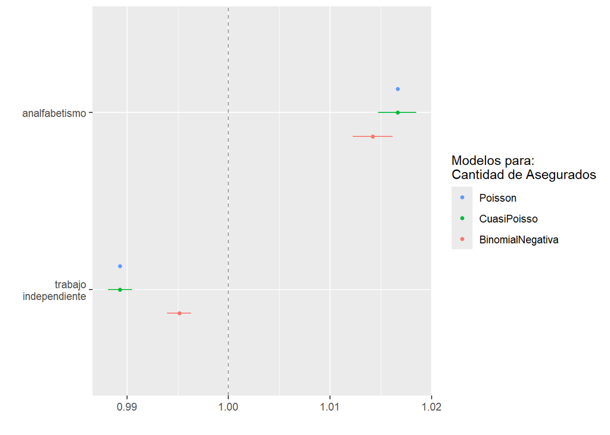

```r
library(ggplot2)
dotwhisker::dwplot(list(Poisson=rp2,CuasiPoisso=rqp,BinomialNegativa=rbn),exp=T) + scale_y_discrete(labels=c("trabajo\nindependiente","analfabetismo")) + scale_color_discrete(name="Modelos para:\nCantidad de Asegurados") + geom_vline(
           xintercept = 1,
           colour = "grey60",
           linetype = 2
       )
```

Finalmente, podemos calcular los coeficientes estandarizados (IBM SPSS 2020) para saber cuál de los predictores tiene mayor efecto

```r
sdVD=sd(censo2007_wide_Totales$conSeguro_Total)
sdVIs=apply(censo2007_wide_Totales[,c("analfa_Total","indep_Total")],2,sd)
DF=list(Poisson=sdVIs*coef(rp2)[c(2,3)]/sdVD,
     CuasiPoisson=sdVIs*coef(rqp)[c(2,3)]/sdVD,
     BinomNegativa=sdVIs*coef(rbn)[c(2,3)]/sdVD)%>%
       data.frame()

DF%>% kable(caption = "Coeficientes Standarizados (ordenar vía valores absolutos)")%>%
          kableExtra::kable_styling(full_width = F)
```

Coeficientes Standarizados (ordenar vía valores absolutos)

|  | Poisson | CuasiPoisson | BinomNegativa |
| --- | --- | --- | --- |
| analfa_Total | 8.2e-06 | 8.2e-06 | 7.0e-06 |
| indep_Total | -8.4e-06 | -8.4e-06 | -3.8e-06 |

## 5. Bibliografía

Bobbitt, Zach. 2021. “Negative Binomial Vs. Poisson: How to Choose a Regression Model.” *Statology*. https://www.statology.org/negative-binomial-vs-poisson/.

Choueiry, George. 2022. “Interpret Poisson Regression Coefficients Quantifying Health.” *Quantifying Health*.

Glen, Stephanie. 2016. “Poisson Regression / Regression of Counts: Definition.” *Statistics How To: Elementary Statistics for the Rest of Us!*

Hilbe, Joseph M. 2017. “The Statistical Analysis of Count Data / El Analisis Estadistico de Los Datos de Recuento.” *Cultura y Educación* 29 (3): 409–60. https://doi.org/10.1080/11356405.2017.1368162.

IBM SPSS. 2020. “Computing Standardized Regression Coefficients from GLM Output.” {{CT741}}. https://www.ibm.com/support/pages/computing-standardized-regression-coefficients-glm-output.

INEI. 2007. “Sistema de Difusión de Censos Nacionales.” http://ineidw.inei.gob.pe/ineidw/.

MAGALLANES, Jose Manuel. 2022a. “Estadistica-AnalisisPolitico/Sesion1: Eap2 Classic.” Zenodo. https://doi.org/10.5281/ZENODO.7015029.

———. 2022b. “Estadistica-AnalisisPolitico/Sesion2: Eap2 Innovate.” Zenodo. https://doi.org/10.5281/ZENODO.7017887.